# Part II - Impact of Fan Presence at Stadiums on Home Team Results

## by (Yaw Poku Gyabaah)

## Investigation Overview

> This data set explores whether the abscence of fans from stadiums during the covid period had any impact on match results for english premier league matches played during the 2019/2020 and 2020/2021 seasons.

## Dataset Overview

> The dataset contains data on 760 english premier league matches played during the 2019/2020 and 2020/2021 seasons. There is data on match result, goals scored by home team at half time and at full time, goals scored by away team at half time and at full time, goals scored by half time and goals scored at fulltime.

## Impact of having fans at Stadiums

> The below pie chart shows that the concept of home advantage was very much alive when fans were allowed at stadiums pre-covid. Home teams won a little over 45% of games while away teams won just shy of 31% of games with 24% of games ending in a draw.

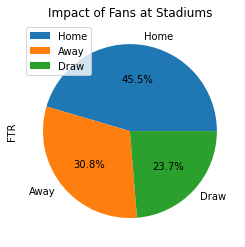

## Impact of having no fans at Stadiums

> The below pie chart confirms that once fans were not allowed into stadiums during the covid pandemic era, the concept of home advantage was virtually wiped away. Both the home team and away team won just above 38% of games played without fans with just over 22% of the games ending in a draw.

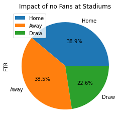

## We now explore how some specific football teams were impacted by having no fans at the stadium for their games during the covid era

## How Liverpool FC were impacted by the playing of matches with no fans at stadiums

> Liverpool FC were hugely impacted by having no fans at Anfield. We can see from the below plot that they won 100% of all matches played at a full Anfield while they only won just about 54% of games played at an empty Anfield.

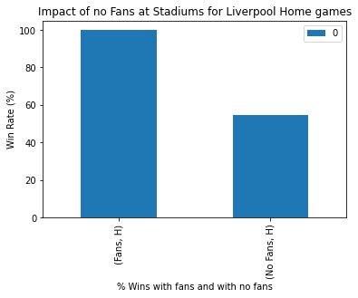

## How Leeds United were impacted by the playing of matches with no fans at stadiums

> Leeds United were also hugely impacted by having no fans at Elland road. We can see that win rate for matches with fans at stadiums was exponentially higher than the win rate for matches played behind closed doors

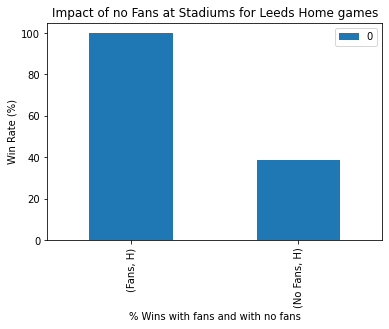

## How Newcastle United were impacted by the playing of matches with no fans at stadiums

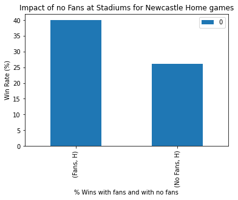

## How Sheffield United were impacted by the playing of matches with no fans at stadiums

> Sheffield United were also hugely impacted by having no fans at Bramall Lane. Their win rate with fans at the stadium was pegged at 50% while they only won 30% of home matches without fans at the stadium.

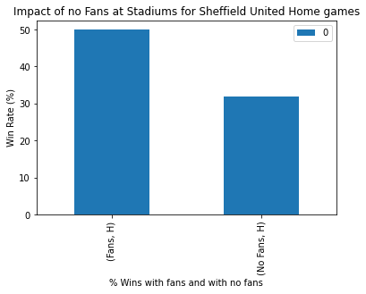

## Beyond exploring how no fans at stadiums affected the home team , we also wanted to explore how away teams were impacted by not having to deal with the pressure of the home fans. We decided to use Manchester United as a test case. Manchester United were chosen because the current iteration of the team seems to wilt under the slightest bit of pressure

## How Manchester United away games were affected by the playing of matches with no fans at stadiums

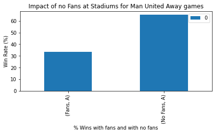